# 01-math-pp-ans

Author

Ragav Rajan S

Published

26-Apr-2025

**Import necessary packages**

```julia
using Latexify
using LaTeXStrings
using DataFramesMeta
using SummaryTables
using Markdown
using Format
using Unitful, UnitfulLatexify
using CairoMakie, AlgebraOfGraphics
Latexify.set_default(; starred=true)
include(joinpath(@__DIR__, "..", "base-functions", "base_functions.jl"))
```

```
table (generic function with 2 methods)
```

# 1

1. In pharmacokinetic studies, which of the following is typically a dependent variable?
- A. Time after drug administration
- **B. Plasma drug concentration**
- C. Volume of distribution
- D. Dose administered

# 2

2. Convert 2.5 milligrams (mg) to micrograms (µg). Show your calculation.

```julia
value_mg = 2.5

# Convert mg -> µg
value_µg = value_mg * 1e3   # 1 mg = 1000 µg

println("value in mg  : ", value_mg, " mg")
println("value in µg  : ", value_µg, " µg")
```

```
value in mg  : 2.5 mg
value in µg  : 2500.0 µg
```

# 3

3. A drug’s clearance is 3 L/hour. Convert this value to mL/min. (Hint: 1 L = 1000 mL, 1 hour = 60 min)

```julia
drug_cl = 3

# Convert L/h to mL/min
drug_cl_ml_min = drug_cl * (1000/60) # 1 L/h = (1000/60) mL/min

println("value in L/h  : ", drug_cl, " L/h")
println("value in mL/min : ", drug_cl_ml_min, " mL/min")
```

```
value in L/h  : 3 L/h
value in mL/min : 50.0 mL/min
```

# 4

4. Round the value 12.3456 mg/L to three significant digits.

```julia
conc = 12.3456
sigdigit = 3

r1 = round(conc, sigdigits = sigdigit)

println("Original conc = ", conc)
println("Rounded to $sigdigit significant digits = ", r1)
```

```
Original conc = 12.3456
Rounded to 3 significant digits = 12.3
```

# 5

5. Which equation correctly relates the natural logarithm (ln) and base-10 logarithm (log₁₀) of a positive number?
- A. ln(x) = log₁₀(x) / 2.303
- **B. ln(x) = 2.303 . log₁₀**
- C. log₁₀(x) = 2.303 . ln(x)
- D. ln(x) = log₁₀(x)

# 6

6. A drug has a half-life of 4 hours. If 100 mg of the drug is present initially, how much remains after 8 hours (assume first-order elimination)?
- A. 50 mg
- **B. 25 mg**
- C. 12.5 mg
- D. 12.5 mg

```julia
tₕ = 4
Doseₒ = 100
V = 1; # considering a fixed volume 1 mL
```

$$tₕ = \frac{0.693}{k}$$

```julia
k = 0.693 / tₕ
println("The first order rate constant is ", k, " h⁻¹")
```

```
The first order rate constant is 0.17325 h⁻¹
```

$$C = \frac{Dose_0}{V} \cdot e^{-kt} \quad \text{[Concentration at a given time]}$$

After 8 hrs, t = 8

```julia
t = 8
C = Doseₒ / V *  ℯ^(-k*t)

println("The amount of drug that remains after $t hours is $(round(C)) mg")
```

```
The amount of drug that remains after 8 hours is 25.0 mg
```

# 7

7. The term `dC/dt` in a pharmacokinetic equation represents:
- A. a drug concentration at time t.
- **B. the rate of change of concentration with respect to time.**
- C. the time it takes for concentration to change by 1 unit.
- D. a constant volume.

# 8

8. What does the area under the plasma concentration–time curve (AUC) from time 0 to infinity represent?
- **A. The total drug exposure over time.**
- B. The maximum plasma concentration achieved.
- C. The clearance of the drug from the body.
- D. The elimination half-life of the drug.

# 9

9. For a first-order elimination rate constant (k), if time is measured in hours, what are the units of (k)?

**hours⁻¹**

# 10

10. The elimination half-life $t_{1/2}$ is related to the rate constant k by the equation $t_{1/2} = \frac{0.693}{k}$

$k = 0.693 / t_{1/2}$

11-15. A patient is given a single **intravenous bolus** dose of **500 mg** of Drug X. The drug’s volume of distribution is **Vd = 50 L** and its clearance is **CL = 5 L/hour**. Assume a one-compartment model with first-order elimination.

# 11

11. Using the scenario above, calculate the **initial plasma drug concentration** $C_0$ immediately after the IV bolus dose (at t = 0). *Hint: assume instant distribution of the dose in the volume of distribution.*

```julia
Dose = 500
Vd = 50
CL = 5

Cₒ = Dose/Vd

println("The initial concentration is $Cₒ mg/L.")
```

```
The initial concentration is 10.0 mg/L.
```

# 12

12. Calculate the **elimination rate constant** k for Drug X using the provided clearance and volume of distribution (CL and Vd).

$k = \frac{CL}{V_d}$

```julia
k = CL / Vd

println("The elimination rate constant for Drug X is $k h⁻¹")
```

```
The elimination rate constant for Drug X is 0.1 h⁻¹
```

# 13

13. Using your result from question 12, calculate the elimination half-life $t_\frac{1}{2}$ of Drug X.

$t_\frac{1}{2} = \frac{0.693}{k}$

```julia
tₕ = 0.693/k

println("The elimination half-life for Drug X is $(round(tₕ, digits=3)) hours")
```

```
The elimination half-life for Drug X is 6.93 hours
```

# 14

14. Write the formula for the **plasma concentration as a function of time** $C(t)$, for Drug X in this one-compartment model. (Use the values $C_0$ and $k$ from the scenario in your expression.)

$$C(t) = C_0 . e^{-kt}$$

# 15

15. Using the formula from question 14, calculate the plasma drug concentration at t = 4 hours for Drug X.

```julia
t = 4

println("Cₒ = $Cₒ mg/L")
println("k = $k h⁻¹")
println("t = $t h")

Cₜ = Cₒ * ℯ^(-k*t)

println("\nThe plasma drug concentration Cₜ at t = 4 is $Cₜ mg/L")
```

```
Cₒ = 10.0 mg/L
k = 0.1 h⁻¹
t = 4 h

The plasma drug concentration Cₜ at t = 4 is 6.703200460356394 mg/L
```

# 16

16. In another patient, the plasma drug concentration was **80 mg/L at 1 hour** after dosing and **20 mg/L at 5 hours** after dosing. Assuming first-order elimination, calculate the **elimination rate constant** $k$ for this drug in the patient. *(Hint: use the two concentration–time points to solve for $k$.)*

```julia
c₁ = 80
t₁ = 1

c₂ = 20
t₂ = 5;
```

Rate law equation at t₁
$$\begin{align}
\ln(c_1) &= \ln(c_0) - k \cdot t_1 \\
\ln(80) &= \ln(c_0) - k \cdot 1 \tag{1}
\end{align}$$

Rate law equation at t₂
$$\begin{align}
\ln(c_2) &= \ln(c_0) - k \cdot t_2 \\
\ln(20) &= \ln(c_0) - k \cdot 5 \tag{2}
\end{align}$$

Solving for equation (1) and (2)

$$\begin{aligned}
\ln(80) &= \ln(c_0) - k \cdot 1 \\
\ln(20) &= \ln(c_0) - k \cdot 5 \\
\hline
\ln(80) - \ln(20) &= \left( \ln(c_0) - k \cdot 1 \right) - \left( \ln(c_0) - k \cdot 5 \right)
\end{aligned}$$

Final equation
$$\begin{aligned}
\ln(80) - \ln(20) &= 4 \cdot k
\end{aligned}$$

```julia
k = (log(80) - log(20)) / (4)
println("The elimination rate constant is $(round(k, digits=3)) h⁻¹")
```

```
The elimination rate constant is 0.347 h⁻¹
```

# 17

17. Using the $k$ from question 16, calculate the **elimination half-life** of the drug for that patient.

```julia
tₕ = 0.693/k

println("The elimination half life is $(round(tₕ, digits=3)) hours")
```

```
The elimination half life is 2.0 hours
```

# 18

18. Write the **differential equation** describing the rate of change of drug amount $A(t)$ in the body for a continuous **IV infusion** at rate $R_0$ (zero-order input) with first-order elimination (rate constant $k$). *(Assume a one-compartment model and no other losses.)*

To derive the differential equation for the amount of drug $A(t)$ in the body, we’ll consider the following:

- **Zero-order infusion**: The drug is infused at a constant rate $R_0$, meaning the rate of drug input to the body is constant.
- **First-order elimination**: The drug is eliminated from the body at a rate proportional to the amount of drug in the body, with a rate constant $k$.

**Key Assumptions**:

- **One-compartment model**: The drug distributes uniformly in the body and no losses.
- **Continuous IV infusion**: The drug is being infused at a constant rate $R_0$.
- **First-order elimination**: The rate of elimination of the drug is proportional to the amount of drug in the body.

**Steps to derive the differential equation:**

1. **Drug Input**: The rate of drug infusion is constant at $R_0$, so the rate of drug input into the body is

$$\begin{aligned}
\frac{dA}{dt} = R_0
\end{aligned}$$

2. **Drug Output**: The rate of drug elimination is proportional to the amount of drug present in the body, so the rate of elimination is

$$\begin{aligned}
\frac{dA}{dt} = k \cdot A(t)
\end{aligned}$$

where $A(t)$ the amount of drug in the body at time $𝑡$ and $𝑘$ is the first-order rate constant for elimination.

**Final Differential Equation** (Input - output)

$$\begin{aligned}
\frac{dA}{dt} = R_0 - k \cdot A(t)
\end{aligned}$$

Where:

- $A(t)$ is the amount of drug in the body at time $𝑡$.
- $R_0$ is the constant infusion rate (zero-order input).
- $k$ is the first-order elimination rate constant.

This equation describes the rate of change of the drug amount in the body over time.

# 19

19. For the IV bolus **scenario in questions 11–15** (500 mg dose, CL = 5 L/h), calculate the **AUC from 0 to ∞**. Include units in your answer.

```julia
Doseᵢᵥ = 500
CL = 5

AUC₀₋ᵢₙ = Doseᵢᵥ / CL

println("The Area under the curve (0 - ∞) is $AUC₀₋ᵢₙ mg.h/L")
```

```
The Area under the curve (0 - ∞) is 100.0 mg.h/L
```

# 20

20. For a zero-order elimination process with a rate constant $k_0 = 2\, \text{mg/L/hour}$ and an initial concentration $C_0 = 20\, \text{mg/L}$ , how long will it take for the concentration to drop to half of its initial value? Show your calculation.

**Half-life for Zero-order**
$$\begin{aligned}
t_{1/2} = \frac{0.5 \cdot c_0}{k_0}
\end{aligned}$$

```julia
kₒ = 2
cₒ = 20

tₕ = 0.5 * cₒ / kₒ
println("The time taken for the concentration to drop to half its initial value is $tₕ hours")
```

```
The time taken for the concentration to drop to half its initial value is 5.0 hours
```

# 21

21. A drug’s clearance is reported as **5 L/hour** in a 70-kg patient. Convert this clearance to **mL/min/kg**. *(Perform the unit conversions step by step.)*

```julia
CL_old = 5 # L/hour

# Clearance in mL/min
CL_new = CL_old * (1000/60) # 1 L/hour = 1000/60 mL/min

# Clearance in mL/min/kg
CL_new_by_mass = CL_new / 70

println("The value is $(round(CL_new_by_mass, digits = 3)) mL/min/kg")
```

```
The value is 1.19 mL/min/kg
```

# 22

22. A single IV dose of **100 mg** of Drug Y produces an **AUC₀₋∞** of **25 mg·h/L**. Calculate the **clearance (CL)** of Drug Y in L/hour.

```julia
Doseᵢᵥ = 100
AUC₀₋ᵢₙ = 25

CL = Doseᵢᵥ / AUC₀₋ᵢₙ

println("The clearance is $CL L/hour")
```

```
The clearance is 4.0 L/hour
```

# 23

23. Derivation: Show that for a one-compartment model, $CL = k \cdot V_d$

Given:

- A one-compartment model is used.
- $CL$ = Clearance,
- $k$ = Elimination rate constant, and
- $V_d$ = Volume of distribution.
- $AUC_{0-∞}$ = Area Under the Concentration-Time curve.
- $C_0$ = Initial concentration.
- $Dose$

**Step 1: Expression for $AUC_{0-∞}$**

For a one-compartment model, the concentration-time curve follows an exponential decay, and the AUC is the integral of this curve over time.
$$\begin{align}
AUC_{0-∞} = \frac{C_0}{k} \tag{1}
\end{align}$$

**Step 2: Relationship between $C_0$ and $Dose$**

After the dose is administered, the initial concentration in the body is the dose divided by the volume in which the drug is distributed.
$$\begin{align}
C_0 = \frac{Dose}{V_d} \tag{2}
\end{align}$$

**Step 3: Expression for $CL$ from $AUC_{0-∞}$**

Now, the clearance $CL$ is defined as the ratio of the $Dose$ to the area under the concentration-time curve $AUC_{0-∞}$

$$\begin{align}
CL = \frac{Dose}{AUC_{0-∞}} \tag{3}
\end{align}$$

**Step 4: Substitute the expressions for $AUC_{0-∞}$ and $C_0$**

Substituting $(1)$ and $(3)$
$$\begin{align}
CL = \frac{Dose}{\frac{C_0}{k}}
\end{align}$$

Simplifying
$$\begin{align}
CL = \frac{Dose \cdot k}{C_0}
\end{align}$$

Substituting $(2)$
$$\begin{align}
CL = \frac{Dose \cdot k}{\frac{Dose}{V_d}}
\end{align}$$

Thus, we have derived the desired result:

$$\begin{align}
CL = k \cdot V_d
\end{align}$$

# 24

24. A drug’s plasma concentration must drop to **25% of its initial value** before the next dose. If the elimination rate constant is $k = 0.10h^{-1}$, how long will this take? *Show your calculation (solve for time)*.

Assuming IV bolus and 1st order elimination process, the concentration across time $t$ is given by
$$\begin{align}
C(t) = C_0 \cdot e^{-k \cdot t} \tag{1}
\end{align}$$

Concentration reduces to 0.25 of initial value, rewriting the equation $(1)$
$$\begin{align}
0.25 \cdot {C_0} &= C_0 \cdot e^{-k \cdot t} \\
0.25 &= e^{-k \cdot t}
\end{align}$$

Taking Natural log on both sides
$$\begin{align}
\ln{(0.25)} &= \ln{(e^{-k \cdot t})} \\
\ln{(0.25)} &= -k \cdot t
\end{align}$$

Finally
$$t = -\frac{\ln{(0.25)}}{k}$$

```julia
k = 0.10 # h⁻¹
t = -log(0.25)/0.1

print("The time taken to reach 25% of C₀ is $(round(t, digits=3))")
```

```
The time taken to reach 25% of C₀ is 13.863
```

# 25

25. Explain why the half-life of a **first-order** elimination process is constant (independent of concentration), whereas the time to halve the concentration in a **zero-order** process depends on the initial concentration. *Use the mathematical expressions for first-order and zero-order concentration decay to support your explanation.*

| First Order reaction | Zero Order reaction |
| --- | --- |
| $C(t) = C_0 \cdot e^{-k \cdot t}$ | $C(t) = C_0 - k_0 \cdot t$ |
| $C(t_{1/2}) = 0.5 \cdot C_0$ | $C(t_{1/2}) = 0.5 \cdot C_0$ |
| $0.5 = e^-{k \cdot t}$ | $0.5 \cdot C_0 = C_0 - k_0 \cdot t$ |
| $\ln(2) = k \cdot t$ | $0.5 \cdot C_0 = k_0 \cdot t$ |
| $t_{1/2} = \frac{\ln(2)}{k}$ | $t_{1/2} = \frac{0.5 \cdot C_0}{k_0}$ |

# 26

26. Derivation: Solve the differential equation $\frac{dC}{dt} = - k \cdot C$ with initial condition $C\left( 0 \right) = C_{0}$ Show the steps to derive the solution $C(t) = C_0 . e^{-kt}$ (Hint: separate variables and integrate.)

According to rate law,
$$\begin{align}
\frac{dC}{dt} = -k \cdot C
\end{align}$$

Rearranging
$$\begin{align}
\frac{dC}{C} = -k \cdot dt
\end{align}$$

Integrating both sides

$$\begin{align}
\int_{C_0}^{C}\frac{dC}{C} = - \int_{0}^{t} k \cdot dt
\end{align}$$

$$\begin{align}
\ln{(C)} - \ln{(C_0)} = -k \cdot t \\
\ln{(C)} = \ln{(C_0)} - k \cdot t
\end{align}$$

exponentiating both sides
$$\begin{align}
e^{\ln{(C)}} &= e^{\ln{(C_0)} - k \cdot t} \\
C &= C_0 \cdot e^{-k \cdot t}
\end{align}$$

# 27

27. Derivation: Solve the differential equation $dA/dt = R_0 - k \cdot A$ for an infusion with first-order elimination (from question 18). Assume $A(0) = 0$. Provide the expression for $A(t)$. (Hint: this ODE reaches a steady-state as $t \,\to\, ∞$.)

$$\begin{align}
\frac{dA}{dt} + k \cdot A = R_0
\end{align}$$

Multiplying using integrating factor $e^{k \cdot t}$

[if $\frac{dx}{dy} + P(y) \cdot x = Q(t)$, I.F. = $e^{P(t) \cdot dt}$]

$$\begin{equation}
\frac{dA}{dt} \cdot e^{k \cdot t} + k \cdot A \cdot e^{kt} = R_0 \cdot e^{k \cdot t}
\end{equation}$$

Using product rule on LHS
$$\begin{align}
\frac{d}{dt}(A \cdot e^{kt}) = R_0 \cdot e^{k \cdot t}
\end{align}$$

Integrating both sides based on $t$ [$\frac{d}{dx}(F(x)) \cdot dx = F(x) + C$]

$$\begin{align}
\int \frac{d}{dt}(A \cdot e^{kt}) \cdot dt &= \int R_0 \cdot e^{k \cdot t} \cdot dt \\
A(t) \cdot e^{kt} &= \frac{R_0}{k} \cdot e^{k \cdot t} + C
\end{align}$$

Dividing by $e^{kt}$

$$\begin{align}
A(t) = \frac{R_0}{k} + C \cdot e^{-k \cdot t} \tag{1}
\end{align}$$

Applying $A(0) = 0$ and $t = 0$, $C = -\frac{R_0}{k} \tag{2}$

Substituting $(2)$ in $(1)$, The expression for $A(t)$ is:

$$\begin{align}
A(t) &= \frac{R_0}{k} - \frac{R_0}{k} \cdot e^{-k \cdot t} \\
A(t) &= \frac{R_0}{k}(1 - e^{-k \cdot t})
\end{align}$$

As $t \,\to\, ∞$, the exponential term $e^{-k \cdot t} \,\to\, 0$, and the steady-state value of $A(t)$ is:

$$\begin{align}
A_{steady} = \frac{R_0}{k}
\end{align}$$

# 28

28. Using the **trapezoidal rule**, estimate the **AUC from 0 to 8 hours** for Drug Z given the plasma concentration–time data below. Show your calculations for each trapezoid segment.

| Time (h) | Concentration (mg/L) |
| --- | --- |
| 0 | 10.00 |
| 2 | 5.00 |
| 4 | 2.50 |
| 6 | 1.25 |
| 8 | 0.63 |

```julia
# Example data from the table above
times = [0, 2, 4, 6, 8]
concentrations = [10.0, 5.0, 2.5, 1.25, 0.63]

latex_strs = Vector{LaTeXString}()
auci = Vector{Float64}()

# Function to compute AUC using trapezoidal rule
function trapz_auc(t::Vector{Int64}, conc::Vector{Float64})
    if length(t) != length(conc)
        error("Time and concentration vectors must be the same length")
    end

    auc_total = 0.0
    for i in 2:length(times)
        t1 = t[i]
        t2 = t[i-1]
        c1 = conc[i]
        c2 = conc[i-1]

        lstr = @latexdefine AUC = ($c1 + $c2) * ($t1-$t2) / 2 env=:equation

        push!(latex_strs, latexify("$t2 => $t1") * lstr)
        push!(auci, AUC)

        auc_total += AUC
    end

    return auc_total
end

trapz_auc(times, concentrations)
display.(latex_strs);
```

$0 \Rightarrow 2$
$$\begin{equation*}
AUC = \frac{\left( 5.0 + 10.0 \right) \cdot \left( 2 - 0 \right)}{2} = 15.0
\end{equation*}$$

$2 \Rightarrow 4$
$$\begin{equation*}
AUC = \frac{\left( 2.5 + 5.0 \right) \cdot \left( 4 - 2 \right)}{2} = 7.5
\end{equation*}$$

$4 \Rightarrow 6$
$$\begin{equation*}
AUC = \frac{\left( 1.25 + 2.5 \right) \cdot \left( 6 - 4 \right)}{2} = 3.75
\end{equation*}$$

$6 \Rightarrow 8$
$$\begin{equation*}
AUC = \frac{\left( 0.63 + 1.25 \right) \cdot \left( 8 - 6 \right)}{2} = 1.88
\end{equation*}$$

```julia
expr = :($(join(string.(auci), " + ")))
equation = Meta.parse(string(expr))
latexify(string("AUC_total => ", equation, " = ", eval(equation)))
```

$AUC_{total} \Rightarrow 15.0 + 7.5 + 3.75 + 1.88 = 28.13$

# 29

29. Consider a **two-compartment model** with a central compartment (1) and a peripheral compartment (2). Let $k_{12}$ be the rate constant for drug transfer from compartment 1 to 2, $k_{21}$ the transfer from 2 to 1, and $k_{10}$ the elimination rate constant from compartment 1 (to outside the system). **Write the differential equations** for the change in drug amounts $A_{1}(t)$ and $A_{2}(t)$ in each compartment over time.

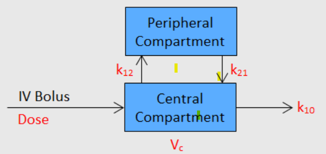

$Dose (D)$ is the administered dose, mg

$Vc$ is the volume of distribution of the central compartment, litres

$k_{12}$ is the first order transfer rate constant from the central to the peripheral compartment, hour-1

$k_{21}$ is the first order transfer rate constant from the peripheral to the central compartment, hour-1

$k_{10}$ is the first order elimination rate constant from the central compartment, hour-1

$$\begin{equation}
\frac{dA_{1}}{dt} = k_{21} \cdot A_{2} - k_{12} \cdot A_{1} - k_{10} \cdot A_{1}
\end{equation}$$

$$\begin{equation}
\frac{dA_{2}}{dt} = k_{12} \cdot A_{1} - k_{21} \cdot A_{2}
\end{equation}$$

# 30

30. For a first-order elimination process, approximately **how many half-life periods** are needed for more than **95%** of the drug to be eliminated from the body? Justify your answer with calculations or reasoning

```julia
full = 100
i = 1
lst = Vector{LaTeXString}()

while full > 100 - 95
  full = full / 2
  num_l = latexify(full)
  num_l1 = latexify(100-full)
  push!(lst, "C => C/2 after $i half-life => " * num_l * "% remains (" * num_l1 * "% eliminated)")
  i += 1
end

display.(lst);
md"From the above calculation, 95% of the drug is eliminated after 5 lives."
```

C => C/2 after 1 half-life => $50.0$% remains ($50.0$% eliminated)

C => C/2 after 2 half-life => $25.0$% remains ($75.0$% eliminated)

C => C/2 after 3 half-life => $12.5$% remains ($87.5$% eliminated)

C => C/2 after 4 half-life => $6.25$% remains ($93.75$% eliminated)

C => C/2 after 5 half-life => $3.125$% remains ($96.875$% eliminated)

From the above calculation, 95% of the drug is eliminated after 5 lives.